# Investigating the Attributes of Successful Movie Releases

- Introduction
- Data Wrangling
- Exploratory Data Analysis
- Conclusion
- Limitations

# Introduction

Online blogs, a friend's reccommendation, box office sales' figures... the list goes on and on. There are numerous ways to determine if a film was successful. What if there was a common pattern among films; patterns that could help in determining its success before its release date? In this data exploration, different movie characteristics will be analyzed to find patterns and spot correlations pertaining to production success.

The dataset that will be covered in this data exploration is the **[TMDB Movie Dataset](https://www.kaggle.com/tmdb/tmdb-movie-metadata)** from Kaggle, an open-source database.

## Focus

The focus of the data analysis is centered around finding correlations between movie properties and their release success. Our basis of success will be metrics centred around the movie revenue, profit, and audience rating. These success metrics will act as the dependent variables in the data analysis. The indepdendent variables will consist of metrics such as movie genre, runtime, initial budget, director and crew involved included in the dataset.

The questions to be explored in this data analysis are:

- What kind of movie properties, cast members, and production companies have resulted in higher profits?

Answering this question is essential to answering the main concept of this data analysis which is to examine the main independent variables and their impact on the dependent variable: profit.

- Which genres require a higher budget and which ones have a higher runtime? What is the correlation between a movie's runtime and their budget?

Taking a closer dive into what which genres require the most allocation of budget. When it is understood which budgets drive the highest profit margins, understanding which genres require the highest budget indicates whether the genre is costly but also generating a lot of revenue. In addition, analyzing the genre's runtime can indicate whether runtime, which has a positive correlation to profit, can also be influenced with the genres.

- What are the trends in movie productions over the past 10 years in terms of budget, profit, and fan ratings?

Understanding the trends in profit and initial budget can indicate whether technological advances has aided the profitability of movies. Has technology and movie advancements played a role in how profitable modern movies are? Do modern movies require more budget than historical films?

- How does the release month relate to a movie's success?

Release month also acts as an independent variable to a movie's success. Deciphering whether each month has an impact on the average profitability of a film can help in determining if release month is a valid independent variable that has an effect in movie profit.

- What are the top 10 most profitable movies?

The Top 10 most profitable movies provide little to no value to the data analysis but was of one's own curiosity.

# Data Wrangling

```python
# Importing libraries
import pandas as pd
import numpy as np
import matplotlib.pyplot as plt
import seaborn as sns
%matplotlib inline

# Loading dataset
df = pd.read_csv('tmdb-movies.csv')
```

### General Properties

```python
df.head(1)
```

|  | id | imdb_id | popularity | budget | revenue | original_title | cast | homepage | director | tagline | ... | overview | runtime | genres | production_companies | release_date | vote_count | vote_average | release_year | budget_adj | revenue_adj |
| --- | --- | --- | --- | --- | --- | --- | --- | --- | --- | --- | --- | --- | --- | --- | --- | --- | --- | --- | --- | --- | --- |
| 0 | 135397 | tt0369610 | 32.985763 | 150000000 | 1513528810 | Jurassic World | Chris Pratt\|Bryce Dallas Howard\|Irrfan Khan\|Vi... | http://www.jurassicworld.com/ | Colin Trevorrow | The park is open. | ... | Twenty-two years after the events of Jurassic ... | 124 | Action\|Adventure\|Science Fiction\|Thriller | Universal Studios\|Amblin Entertainment\|Legenda... | 6/9/15 | 5562 | 6.5 | 2015 | 1.379999e+08 | 1.392446e+09 |

1 rows × 21 columns

```python
df.shape
```

```
(10866, 21)
```

```python
df.describe()
```

|  | id | popularity | budget | revenue | runtime | vote_count | vote_average | release_year | budget_adj | revenue_adj |
| --- | --- | --- | --- | --- | --- | --- | --- | --- | --- | --- |
| count | 10866.000000 | 10866.000000 | 1.086600e+04 | 1.086600e+04 | 10866.000000 | 10866.000000 | 10866.000000 | 10866.000000 | 1.086600e+04 | 1.086600e+04 |
| mean | 66064.177434 | 0.646441 | 1.462570e+07 | 3.982332e+07 | 102.070863 | 217.389748 | 5.974922 | 2001.322658 | 1.755104e+07 | 5.136436e+07 |
| std | 92130.136561 | 1.000185 | 3.091321e+07 | 1.170035e+08 | 31.381405 | 575.619058 | 0.935142 | 12.812941 | 3.430616e+07 | 1.446325e+08 |
| min | 5.000000 | 0.000065 | 0.000000e+00 | 0.000000e+00 | 0.000000 | 10.000000 | 1.500000 | 1960.000000 | 0.000000e+00 | 0.000000e+00 |
| 25% | 10596.250000 | 0.207583 | 0.000000e+00 | 0.000000e+00 | 90.000000 | 17.000000 | 5.400000 | 1995.000000 | 0.000000e+00 | 0.000000e+00 |
| 50% | 20669.000000 | 0.383856 | 0.000000e+00 | 0.000000e+00 | 99.000000 | 38.000000 | 6.000000 | 2006.000000 | 0.000000e+00 | 0.000000e+00 |
| 75% | 75610.000000 | 0.713817 | 1.500000e+07 | 2.400000e+07 | 111.000000 | 145.750000 | 6.600000 | 2011.000000 | 2.085325e+07 | 3.369710e+07 |
| max | 417859.000000 | 32.985763 | 4.250000e+08 | 2.781506e+09 | 900.000000 | 9767.000000 | 9.200000 | 2015.000000 | 4.250000e+08 | 2.827124e+09 |

```python
df.nunique()
```

```
id                      10865
imdb_id                 10855
popularity              10814
budget                    557
revenue                  4702
original_title          10571
cast                    10719
homepage                 2896
director                 5067
tagline                  7997
keywords                 8804
overview                10847
runtime                   247
genres                   2039
production_companies     7445
release_date             5909
vote_count               1289
vote_average               72
release_year               56
budget_adj               2614
revenue_adj              4840
dtype: int64
```

### Checking for Field Relevancy

Determining whether each field included in the database is relevant to the objective of the data analysis.

Fields such as "id", "imdb_id", "homepage", and "tagline" are irrelevant fields to the data analysis.

In addition, the "budget" and "revenue" fields can be replaced by the adjusted values of these fields, as to keep account for inflation when comparing monetary values. The "keywords" and "overview" are general descriptors of the different movies, and will not be used in this analysis.

The "release_date" field will be used instead of the "release_year" field to include the impact of release month when analyzing release dates' impact on production success. We will, however, store the release year records for data cleaning purposes explained further in the analysis.

```python
release_years = df['release_year']
df.drop(['id', 'imdb_id', 'homepage', 'tagline', 'budget', 'revenue', 'release_year', 'keywords', 'overview'], axis=1, inplace=True)
df.head(1)
```

|  | popularity | original_title | cast | director | runtime | genres | production_companies | release_date | vote_count | vote_average | budget_adj | revenue_adj |
| --- | --- | --- | --- | --- | --- | --- | --- | --- | --- | --- | --- | --- |
| 0 | 32.985763 | Jurassic World | Chris Pratt\|Bryce Dallas Howard\|Irrfan Khan\|Vi... | Colin Trevorrow | 124 | Action\|Adventure\|Science Fiction\|Thriller | Universal Studios\|Amblin Entertainment\|Legenda... | 6/9/15 | 5562 | 6.5 | 1.379999e+08 | 1.392446e+09 |

### Creating the Profit Column

By creating the profit field in the dataframe, an additional dependent variable can be added.

```python
df['profit'] = df['revenue_adj'] - df['budget_adj']
df.head(1)
```

|  | popularity | original_title | cast | director | runtime | genres | production_companies | release_date | vote_count | vote_average | budget_adj | revenue_adj | profit |
| --- | --- | --- | --- | --- | --- | --- | --- | --- | --- | --- | --- | --- | --- |
| 0 | 32.985763 | Jurassic World | Chris Pratt\|Bryce Dallas Howard\|Irrfan Khan\|Vi... | Colin Trevorrow | 124 | Action\|Adventure\|Science Fiction\|Thriller | Universal Studios\|Amblin Entertainment\|Legenda... | 6/9/15 | 5562 | 6.5 | 1.379999e+08 | 1.392446e+09 | 1.254446e+09 |

### Describing Finalized Fields

**popularity**: Numeric rating based on user interactivity with movie on TMDB website and platforms.  
**original_title**: Title of the movie.  
**cast**: Actors involved in the movie.  
**director**: Director of the movie.  
**runtime**: Total duration of the movie (minutes).  
**genres**: The multiple genres of the movie.  
**production_companies**: The production companies involved in the making of the movie.  
**vote_count**: Number of votes cast for the movie rating.  
**vote_average**: Average movie rating cast.  
**budget_adj**: Total value invested into the production of the movie adjusted for inflation (2010).  
**revenue_adj**: Total revenue acquired from the movie adjusted for inflation (2010).  
**profit**: Total movie profit adjusted for inflation (2010).

### Verifying Record Completeness

```python
df.shape[0]
```

```
10866
```

There are 10,866 movies recorded in the dataset.

Each field should have 10,866 values for each movie. We can check if any value in each field is incomplete through the following loop which returns a list of columns that have null values within them.

```python
incomplete_fields = [column for column in df.columns if df[column].isnull().any()]
incomplete_fields
```

```
['cast', 'director', 'genres', 'production_companies']
```

All of the column names in the "incomplete_fields" list are fields that have incomplete missing record information. We can verify this by calling the .info() method which provides information about the amount of entries and the data type of each field. The number of records per field must equal 10,866, the number of movies in the dataset. Each field that includes less entries than the number of movies is incomplete.

```python
df.info()
```

```
<class 'pandas.core.frame.DataFrame'>
RangeIndex: 10866 entries, 0 to 10865
Data columns (total 13 columns):
 #   Column                Non-Null Count  Dtype
---  ------                --------------  -----
 0   popularity            10866 non-null  float64
 1   original_title        10866 non-null  object
 2   cast                  10790 non-null  object
 3   director              10822 non-null  object
 4   runtime               10866 non-null  int64
 5   genres                10843 non-null  object
 6   production_companies  9836 non-null   object
 7   release_date          10866 non-null  object
 8   vote_count            10866 non-null  int64
 9   vote_average          10866 non-null  float64
 10  budget_adj            10866 non-null  float64
 11  revenue_adj           10866 non-null  float64
 12  profit                10866 non-null  float64
dtypes: float64(5), int64(2), object(6)
memory usage: 1.1+ MB
```

It can be confirmed that the "incomplete_list" includes all fields that have some null entries. It is important to note that all fields are of the String data type. They will be corrected when analyzing non-quantitative properties.

### Correcting Data Types

From calling the .info() method, it can be observed that all fields but the "release_date" are in proper format. Currently, the "release_date" field is of the String data type when it should be of the datetime data type.

```python
## df['release_date'] =  pd.to_datetime(df['release_date'], format='%m/%d/%y')
```

The previous piece of code converts all String types to a datetime type. However, because a record such as 1966 is represented as mm/dd/yy, the datetime records it as the year 2066. A simple fix is to use the year release date series that was stored before the dropping of columns.

```python
df['release_date'] = df.release_date.apply(lambda x: '/'.join(x.split('/')[:2]))
df['release_date']
```

```
0          6/9
1         5/13
2         3/18
3        12/15
4          4/1
         ...
10861     6/15
10862    12/21
10863      1/1
10864     11/2
10865    11/15
Name: release_date, Length: 10866, dtype: object
```

```python
df['release_date'] = df.release_date + "/" + release_years.astype(str)
df['release_date']
```

```
0          6/9/2015
1         5/13/2015
2         3/18/2015
3        12/15/2015
4          4/1/2015
            ...
10861     6/15/1966
10862    12/21/1966
10863      1/1/1966
10864     11/2/1966
10865    11/15/1966
Name: release_date, Length: 10866, dtype: object
```

Now that the release_date field is in correct String format, it allows for seamless conversion to the datetime datatype.

```python
df['release_date'] =  pd.to_datetime(df['release_date'], format='%m/%d/%Y')
df['release_date']
```

```
0       2015-06-09
1       2015-05-13
2       2015-03-18
3       2015-12-15
4       2015-04-01
           ...
10861   1966-06-15
10862   1966-12-21
10863   1966-01-01
10864   1966-11-02
10865   1966-11-15
Name: release_date, Length: 10866, dtype: datetime64[ns]
```

### Deleting Duplicate Movie Entries

It is essential to check for duplicate entries as to not have duplicate values influence the conclusions of the analysis.

```python
df.duplicated().sum()
```

```
1
```

There is 1 duplicate value to be removed.

```python
df.drop_duplicates()
```

|  | popularity | original_title | cast | director | runtime | genres | production_companies | release_date | vote_count | vote_average | budget_adj | revenue_adj | profit |
| --- | --- | --- | --- | --- | --- | --- | --- | --- | --- | --- | --- | --- | --- |
| 0 | 32.985763 | Jurassic World | Chris Pratt\|Bryce Dallas Howard\|Irrfan Khan\|Vi... | Colin Trevorrow | 124 | Action\|Adventure\|Science Fiction\|Thriller | Universal Studios\|Amblin Entertainment\|Legenda... | 2015-06-09 | 5562 | 6.5 | 1.379999e+08 | 1.392446e+09 | 1.254446e+09 |
| 1 | 28.419936 | Mad Max: Fury Road | Tom Hardy\|Charlize Theron\|Hugh Keays-Byrne\|Nic... | George Miller | 120 | Action\|Adventure\|Science Fiction\|Thriller | Village Roadshow Pictures\|Kennedy Miller Produ... | 2015-05-13 | 6185 | 7.1 | 1.379999e+08 | 3.481613e+08 | 2.101614e+08 |
| 2 | 13.112507 | Insurgent | Shailene Woodley\|Theo James\|Kate Winslet\|Ansel... | Robert Schwentke | 119 | Adventure\|Science Fiction\|Thriller | Summit Entertainment\|Mandeville Films\|Red Wago... | 2015-03-18 | 2480 | 6.3 | 1.012000e+08 | 2.716190e+08 | 1.704191e+08 |
| 3 | 11.173104 | Star Wars: The Force Awakens | Harrison Ford\|Mark Hamill\|Carrie Fisher\|Adam D... | J.J. Abrams | 136 | Action\|Adventure\|Science Fiction\|Fantasy | Lucasfilm\|Truenorth Productions\|Bad Robot | 2015-12-15 | 5292 | 7.5 | 1.839999e+08 | 1.902723e+09 | 1.718723e+09 |
| 4 | 9.335014 | Furious 7 | Vin Diesel\|Paul Walker\|Jason Statham\|Michelle ... | James Wan | 137 | Action\|Crime\|Thriller | Universal Pictures\|Original Film\|Media Rights ... | 2015-04-01 | 2947 | 7.3 | 1.747999e+08 | 1.385749e+09 | 1.210949e+09 |
| ... | ... | ... | ... | ... | ... | ... | ... | ... | ... | ... | ... | ... | ... |
| 10861 | 0.080598 | The Endless Summer | Michael Hynson\|Robert August\|Lord 'Tally Ho' B... | Bruce Brown | 95 | Documentary | Bruce Brown Films | 1966-06-15 | 11 | 7.4 | 0.000000e+00 | 0.000000e+00 | 0.000000e+00 |
| 10862 | 0.065543 | Grand Prix | James Garner\|Eva Marie Saint\|Yves Montand\|Tosh... | John Frankenheimer | 176 | Action\|Adventure\|Drama | Cherokee Productions\|Joel Productions\|Douglas ... | 1966-12-21 | 20 | 5.7 | 0.000000e+00 | 0.000000e+00 | 0.000000e+00 |
| 10863 | 0.065141 | Beregis Avtomobilya | Innokentiy Smoktunovskiy\|Oleg Efremov\|Georgi Z... | Eldar Ryazanov | 94 | Mystery\|Comedy | Mosfilm | 1966-01-01 | 11 | 6.5 | 0.000000e+00 | 0.000000e+00 | 0.000000e+00 |
| 10864 | 0.064317 | What's Up, Tiger Lily? | Tatsuya Mihashi\|Akiko Wakabayashi\|Mie Hama\|Joh... | Woody Allen | 80 | Action\|Comedy | Benedict Pictures Corp. | 1966-11-02 | 22 | 5.4 | 0.000000e+00 | 0.000000e+00 | 0.000000e+00 |
| 10865 | 0.035919 | Manos: The Hands of Fate | Harold P. Warren\|Tom Neyman\|John Reynolds\|Dian... | Harold P. Warren | 74 | Horror | Norm-Iris | 1966-11-15 | 15 | 1.5 | 1.276423e+05 | 0.000000e+00 | -1.276423e+05 |

10865 rows × 13 columns

### Addressing Multiple Values for a Single Entry

The cast, genres, and production companies all have "|"-seperated values indicating a list of different values. We can correct this formatting using the get_dummies() function which allows for the values to be seperated into binary columns for each row. After attempting this direction, there were difficulties in converting the data into graphable categories. The one hot encoding is more suitable for machine learning applications. The explode() method seems like the right direction to take, which splits each created list item for each row into multiple values. The genre_df will be used to compare quantitative values to the categorical data of genres.

```python
def seperateListings(originalDF, column_name):
    new_df = df.copy()
    new_df = new_df.dropna()
    new_df[column_name] = new_df[column_name].apply(lambda x : x.split("|"))
    new_df = new_df.explode(column_name)
    return new_df


genre_df = seperateListings(df, "genres")
genre_df.head(5)
```

|  | popularity | original_title | cast | director | runtime | genres | production_companies | release_date | vote_count | vote_average | budget_adj | revenue_adj | profit |
| --- | --- | --- | --- | --- | --- | --- | --- | --- | --- | --- | --- | --- | --- |
| 0 | 32.985763 | Jurassic World | Chris Pratt\|Bryce Dallas Howard\|Irrfan Khan\|Vi... | Colin Trevorrow | 124 | Action | Universal Studios\|Amblin Entertainment\|Legenda... | 2015-06-09 | 5562 | 6.5 | 1.379999e+08 | 1.392446e+09 | 1.254446e+09 |
| 0 | 32.985763 | Jurassic World | Chris Pratt\|Bryce Dallas Howard\|Irrfan Khan\|Vi... | Colin Trevorrow | 124 | Adventure | Universal Studios\|Amblin Entertainment\|Legenda... | 2015-06-09 | 5562 | 6.5 | 1.379999e+08 | 1.392446e+09 | 1.254446e+09 |
| 0 | 32.985763 | Jurassic World | Chris Pratt\|Bryce Dallas Howard\|Irrfan Khan\|Vi... | Colin Trevorrow | 124 | Science Fiction | Universal Studios\|Amblin Entertainment\|Legenda... | 2015-06-09 | 5562 | 6.5 | 1.379999e+08 | 1.392446e+09 | 1.254446e+09 |
| 0 | 32.985763 | Jurassic World | Chris Pratt\|Bryce Dallas Howard\|Irrfan Khan\|Vi... | Colin Trevorrow | 124 | Thriller | Universal Studios\|Amblin Entertainment\|Legenda... | 2015-06-09 | 5562 | 6.5 | 1.379999e+08 | 1.392446e+09 | 1.254446e+09 |
| 1 | 28.419936 | Mad Max: Fury Road | Tom Hardy\|Charlize Theron\|Hugh Keays-Byrne\|Nic... | George Miller | 120 | Action | Village Roadshow Pictures\|Kennedy Miller Produ... | 2015-05-13 | 6185 | 7.1 | 1.379999e+08 | 3.481613e+08 | 2.101614e+08 |

The same logic with genres also applies with the cast and production companies fields. There will be seperate dataframes created for the purpose of seperating categorical data and comparing it with numerical data.

```python
cast_df = seperateListings(df, 'cast')
company_df = seperateListings(df, 'production_companies')
```

# Exploratory Data Analysis

### What kind of movie properties result in higher profit and fan ratings?

###### Initial Budget

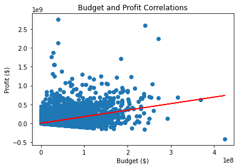

```python
x = df['budget_adj']
y = df['profit']
plt.scatter(x, y)

m, b = np.polyfit(x, y, 1)
plt.plot(x, m*x + b,color="r")

plt.title('Budget and Profit Correlations')
plt.xlabel('Budget ($)')
plt.ylabel('Profit ($)')

plt.show()
```

The chart describes the correlation between the allocated budget and the profit generated by movies. As observed from the plot, there is a positive correlation between the initial budget of a movie and the profit it generates. It can be concluded that a higher initial budget leads to a higher average profit.

###### Runtime

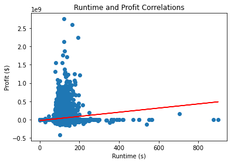

```python
x = df['runtime']
y = df['profit']
plt.scatter(x, y)

m, b = np.polyfit(x, y, 1)
plt.plot(x, m*x + b,color="r")

plt.title('Runtime and Profit Correlations')
plt.xlabel('Runtime (s)')
plt.ylabel('Profit ($)')

plt.show()
```

The chart depicts the correlation between the runtime and the profit generated by movies. As observed from the plot, there is a slightly positive correlation between the runtime of a film and the profit it generates. It can be concluded that a higher runtime leads to a higher average profit.

###### Genre

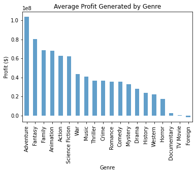

```python
genre_profit = genre_df.groupby('genres')['profit'].mean().sort_values(ascending=False)
genre_profit.plot(kind='bar', title='Average Profit Generated by Genre', alpha=.7);
plt.xlabel('Genre')
plt.ylabel('Profit ($)')
```

This chart depicts the average profit that each genre produces. The plot indicates that the adventure, fantasy, and family genres generate the most revenue and profit. The least profitable genres are foreign, TV Movie, and Documentary films.

###### Top 10 Cast Members

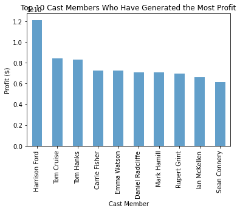

```python
cast_profit = cast_df.groupby('cast')['profit'].sum().sort_values(ascending=False)[0:10]
cast_profit.plot(kind='bar', title='Top 10 Cast Members Who Have Generated the Most Profit', alpha=.7);
plt.xlabel('Cast Member')
plt.ylabel('Profit ($)')
```

The chart depicts the top 10 cast members who have amassed the most profit in the films they featured in are listed. It can be inferred that the actors described above feature in high-grossing films.

###### Top 10 Production Companies

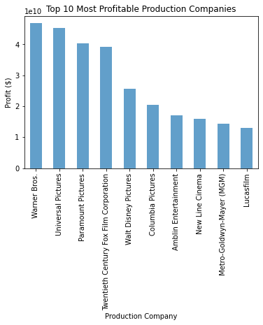

```python
company_profit = company_df.groupby('production_companies')['profit'].sum().sort_values(ascending=False)[0:10]
company_profit.plot(kind='bar', title='Top 10 Most Profitable Production Companies', alpha=.7);
plt.xlabel('Production Company')
plt.ylabel('Profit ($)')
```

The chart depicts the top 10 most profitable production companies. From this depiction, it can be concluded that any movie produced by these companies has a likely chance that it will generate a substantial bottom line.

The movie properties that were examined were initial budget, runtime, cast members, and production companies. The initial budget and runtime both had positive correlations with profitability. The top 10 cast members and production companies were able to provide an indication as to which featured members or companies were associated with a higher profit margin.

### Which genres require a higher budget and which ones have a higher runtime? What is the correlation between a movie's runtime and their budget?

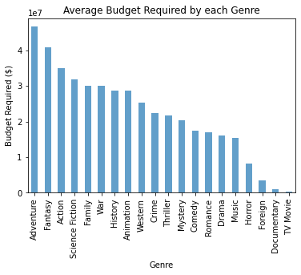

```python
genre_profit = genre_df.groupby('genres')['budget_adj'].mean().sort_values(ascending=False)
genre_profit.plot(kind='bar', title='Average Budget Required by each Genre', alpha=.7);
plt.xlabel('Genre')
plt.ylabel('Budget Required ($)')
```

The histogram depicts the average initial budget each genre requires. The plot indicates that the adventure, fantasy, and action movies require the highest budget to produce while Foreign, Documentary, and TV Movies require the least amount of budget.

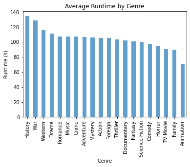

```python
genre_profit = genre_df.groupby('genres')['runtime'].mean().sort_values(ascending=False)
genre_profit.plot(kind='bar', title='Average Runtime by Genre', alpha=.7);
plt.xlabel('Genre')
plt.ylabel('Runtime (s)')
```

The chart depicts the average runtime of each genre. As observed from the graph, the History, War, and Western genres were the genres with the highest average runtimes, while the TV Movie, Family, and Animation were the lowest average runtimes.

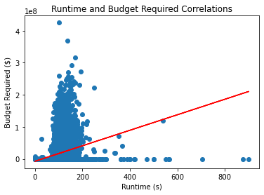

```python
x = df['runtime']
y = df['budget_adj']
plt.scatter(x, y)

m, b = np.polyfit(x, y, 1)
plt.plot(x, m*x + b,color="r")

plt.title('Runtime and Budget Required Correlations')
plt.xlabel('Runtime (s)')
plt.ylabel('Budget Required ($)')

plt.show()
```

The scatter plot represents the relationship between budget allocation and runtime. As observed from the graph, there is a positive correlation between the budget allocated and runtime. This relationship is logical, as a longer runtime may required additional scenes that include additional actors, settings, props, and other components.

In conclusion, there is a positive correlation between a movie's runtime and the budget required to produce the movie.

### What are the trends in movie productions over the past 10 years in terms of budget, profit, and fan ratings?

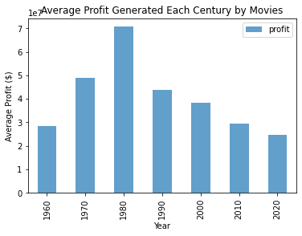

```python
def century_analysis(df, target_column):
    new_df = df.resample("10Y", on='release_date')[[target_column, 'release_date']].mean()
    new_df['year'] = new_df.index.year
    new_df.set_index('year', inplace=True)
    return new_df

century_analysis(df, 'profit').plot(kind='bar', title='Average Profit Generated Each Century by Movies', alpha=.7);
plt.xlabel('Year')
plt.ylabel('Average Profit ($)')
```

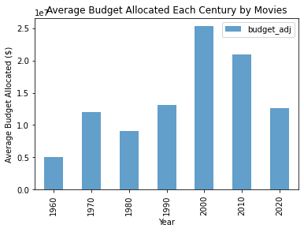

```python
century_analysis(df, 'budget_adj').plot(kind='bar', title='Average Budget Allocated Each Century by Movies', alpha=.7);
plt.xlabel('Year')
plt.ylabel('Average Budget Allocated ($)')
```

The histogram depicts the distribution of average allocated budget over time binned by 10 years. It can be observed that the 2000's featured the highest average allocated budget films while the 1960's featured the lowest. Since the 2000's, allocated film budgets have remained high but have trended down. From the 1960's to the 1990's allocated budget was low. A possible explanation for the jump in initial budget for films during 1990 to 2000 was the high average profitability observed in films during the 1980's as previously observed.

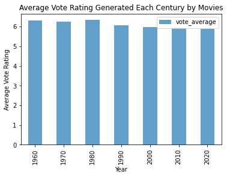

```python
century_analysis(df, 'vote_average').plot(kind='bar', title='Average Vote Rating Generated Each Century by Movies', alpha=.7);
plt.xlabel('Year')
plt.ylabel('Average Vote Rating')
```

Despite fluctuations in average profitbaility over the years, average fan ratings have not seen meaningful change and have hovered in the 6 value rating.

In conclusion, there is seemingly a downward trend for average movie profits in the last 50 years. The most profitable year century for movies was during the 1980's with the average profit being the highest value from the bar chart. However, the 2000th century featured the highest investment and allocated budget for movies, which didn't reflect in the highest profit for that century. Movie ratings remains indifferent over time.

### How does the release month relate to a movie's success?

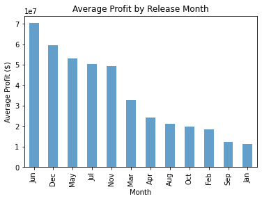

```python
import calendar
df['release_month'] = pd.DatetimeIndex(df['release_date']).month
df['release_month'] = df['release_month'].apply(lambda x: calendar.month_abbr[x])
monthly_analysis = df.groupby('release_month')['profit'].mean().sort_values(ascending=False)

monthly_analysis.plot(kind='bar', title='Average Profit by Release Month', alpha=.7);
plt.xlabel('Month')
plt.ylabel('Average Profit ($)')
```

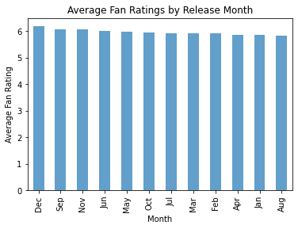

```python
import calendar
monthly_analysis = df.groupby('release_month')['vote_average'].mean().sort_values(ascending=False)

monthly_analysis.plot(kind='bar', title='Average Fan Ratings by Release Month', alpha=.7);
plt.xlabel('Month')
plt.ylabel('Average Fan Rating')
```

The histograph represents the average fan ratings sorted by release month. Like the fan rating comparison over each cycle of 10 years, fan ratings are observed to have no correlation with release month.

The most profitable release month for movies is June followed by December and May. The least profitable release month for movies is January followed by September and February. Release month are observed to have no effect on average fan ratings.

### What are the top 10 most profitable movies?

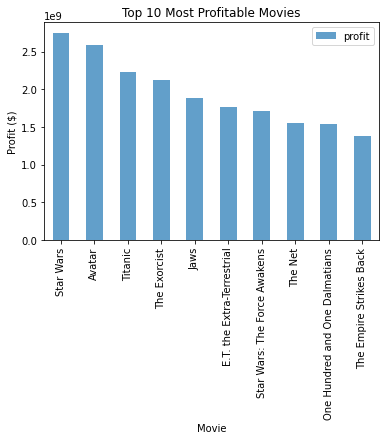

```python
sorted_df = df.sort_values('profit', ascending=False)
successful_movies = sorted_df.head(10)[['original_title', 'profit']]
successful_movies.set_index('original_title', inplace=True)
successful_movies.plot(kind='bar', title='Top 10 Most Profitable Movies', alpha=.7);
plt.xlabel('Movie')
plt.ylabel('Profit ($)')
```

The top 10 movies are described in the above histogram. They include, in order:

1. Star Wars
2. Avatar
3. Titanic
4. The Exorcist
5. Jaws
6. E.T. the Extra-Terrestrial
7. Star Wars: The Force Awakens
8. The Net
9. One Hundrend and One Dalmatians
10. The Empire Strikes Back

# Conclusion

#### Which genres require a higher budget and which ones have a higher runtime? What is the correlation between a movie's runtime and their budget?

The genres which had the highest average budget to produce were adventure, fantasy, and action. The genres with the highest average runtime were history, war, and western. There was a positive correlation between runtime and budget allocated to a production.

#### How does the release month relate to a movie's success?

Movies released in June featured the highest average profit for movies with January being the least average profitable month. No seasonal or cyclical patterns were observed nor where there any correlation of release month with fan ratings.

#### What are the top 10 most profitable movies?

1. Star Wars
2. Avatar
3. Titanic
4. The Exorcist
5. Jaws
6. E.T. the Extra-Terrestrial
7. Star Wars: The Force Awakens
8. The Net
9. One Hundrend and One Dalmatians
10. The Empire Strikes Back

# Limitations

There are several limitations presented in the TMDB dataset and data exploration.

### Early Films

```python
df.tail(3)
```

|  | popularity | original_title | cast | director | runtime | genres | production_companies | release_date | vote_count | vote_average | budget_adj | revenue_adj | profit | release_month |
| --- | --- | --- | --- | --- | --- | --- | --- | --- | --- | --- | --- | --- | --- | --- |
| 10863 | 0.065141 | Beregis Avtomobilya | Innokentiy Smoktunovskiy\|Oleg Efremov\|Georgi Z... | Eldar Ryazanov | 94 | Mystery\|Comedy | Mosfilm | 1966-01-01 | 11 | 6.5 | 0.000000 | 0.0 | 0.000000 | Jan |
| 10864 | 0.064317 | What's Up, Tiger Lily? | Tatsuya Mihashi\|Akiko Wakabayashi\|Mie Hama\|Joh... | Woody Allen | 80 | Action\|Comedy | Benedict Pictures Corp. | 1966-11-02 | 22 | 5.4 | 0.000000 | 0.0 | 0.000000 | Nov |
| 10865 | 0.035919 | Manos: The Hands of Fate | Harold P. Warren\|Tom Neyman\|John Reynolds\|Dian... | Harold P. Warren | 74 | Horror | Norm-Iris | 1966-11-15 | 15 | 1.5 | 127642.279154 | 0.0 | -127642.279154 | Nov |

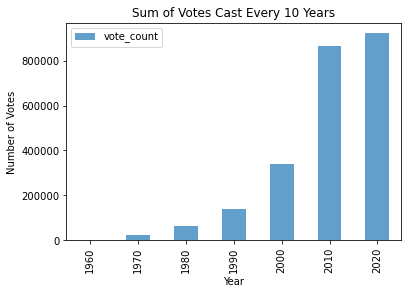

```python
new_df = df.resample("10Y", on='release_date')[['vote_count', 'release_date']].sum()
new_df['year'] = new_df.index.year
new_df.set_index('year', inplace=True)
new_df.plot(kind='bar', title='Sum of Votes Cast Every 10 Years', alpha=.7);
plt.xlabel('Year')
plt.ylabel('Number of Votes')
```

A histograph representing the amount of votes for every 10 years. The graph describes an increase in votes cast over time.

Early developed films like the ones specified above contain numeric values in the budget and revenue columns that are 0. This may not truly reflect the value and success of the film at the time. In addition, although the budget and revenue fields are adjusted for inflation, there have been several technological advancements that have enhanced one's enjoyment and access to movies. The increased access and technological advancements may be factors that affect how earlier films' success is measured relatively to modern made movies. These limitations may affect the time analysis conducted with regards to genre. In addition, although no fluctuations with fan ratings were detected, the number of votes has steadily increased over the years which could affect the accruacy of the mean in earlier films as it is a smaller sample size.

### Distribution of Numeric Values

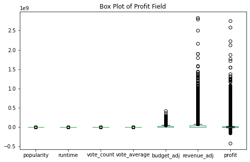

```python
df.plot.box(figsize=(8,5))
plt.title("Box Plot of Profit Field")
```

A box plot representation of the numeric values included in the dataset.